# Tvyal Newsletter

2024-12-17

Հարգելի գործընկեր,

## [💳🚨🏦 Անհուսալի վարկառուների աջակցության ծրագիր. պոպուլիստական քայլ, թե՞ տնտեսական անհրաժեշտություն](https://www.tvyal.com/newsletter/2024/2024_12_17)

2024թ․ դեկտեմբերի 12-ին Կառավարությունը որոշում ընդունեց անհուսալի վարկեր ունեցող քաղաքացիների մի մասի վարկերի ներման վերաբերյալ։ Սա առաջին հայացքից դրական միջոցառում է, սակայն խնդիրն ավելի խորքային է, քանի որ սպառողական վարկերի ծավալը 2018 թվականից սկսած եռապատկվել է, և այդ վարկերի 49 տոկոսը անհուսալի է։

Հայաստանը ներկայումս բախվել է եկամուտների հավաքագրման լուրջ խնդրի։ [Թերի հարկաբյուջետային քաղաքականության](https://www.tvyal.com/newsletter/2024/2024_11_19) հետևանքով 2024 թվականի առաջին 9 ամիսների ընթացքում հավաքագրված հարկերը 8 տոկոսով պակաս են, քան պլանավորված ցուցանիշը։ Վերջին 20 տարվա ընթացքում առաջին անգամ է, որ հավաքագրված հարկերը երեք եռամսյակ շարունակ նշաձողից պակաս են 8 տոկոսով։ Այս պայմաններում նման քաղաքականությունը լրացուցիչ բեռ է առաջացնում բյուջեի վրա։

Գծապատկեր 1

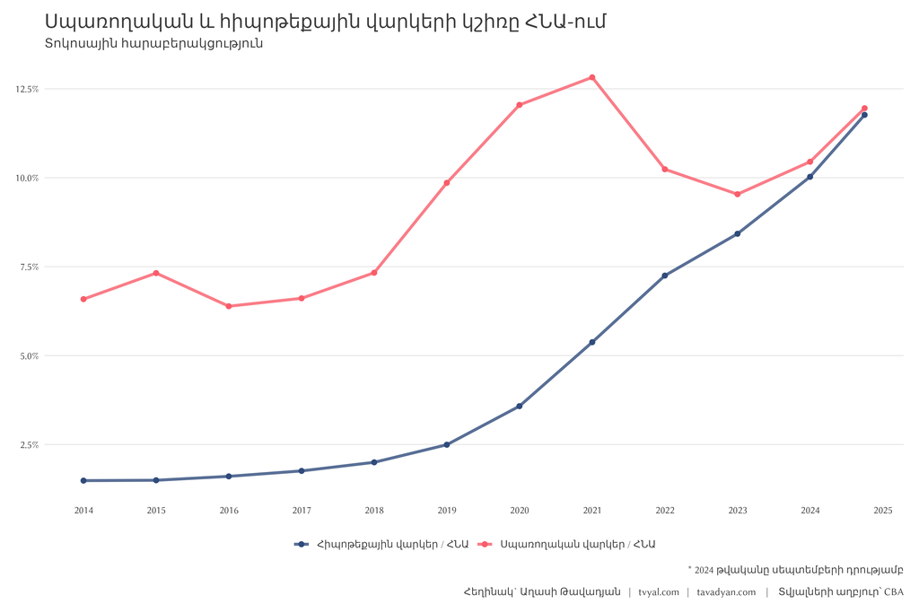

### Կառավարության առաջարկը

Կառավարությունն առաջարկում է մինչև 1 միլիոն դրամ անհուսալի վարկ ունեցող շուրջ 220 հազար քաղաքացիների դուրս գալ ստվերային տնտեսությունից և գրանցվել որպես օրինական աշխատող: Փոխարենը նրանք կստանան երկու տեսակի աջակցություն՝

Հատկանշական է, որ ծրագիրը համընկնում է 2025թ․ հունվարից Երևանում հիպոթեքային վարկերի եկամտահարկի վերադարձի դադարեցման հետ: Նշենք, որ վերջին 3 տարիների ընթացքում այս օրենքի շնորհիվ Ռուսաստանից դուրս եկած դրամական միջոցները հիմնականում ներդրվեցին շինարարությունում, քանի որ այս ոլորտում վարկի տոկոսադրույքը փաստացի զրոյական էր։ Սա հանգեցրեց նրան, որ հատկապես Երևանում սկսեցին կառուցվել նոր շենքեր, որոնք հիմնականում նախատեսված էին միջինից բարձր եկամուտ ունեցող մարդկանց համար։ Քանի որ այս պահին Հայաստանում նկատվում է կապիտալի, ինչպես նաև Ռուսաստանից եկած ռելոկանտների արտահոսք, հարցեր են առաջանում այդ բնակարանների ապագա պահանջարկի վերաբերյալ։

Գծապատկեր 2

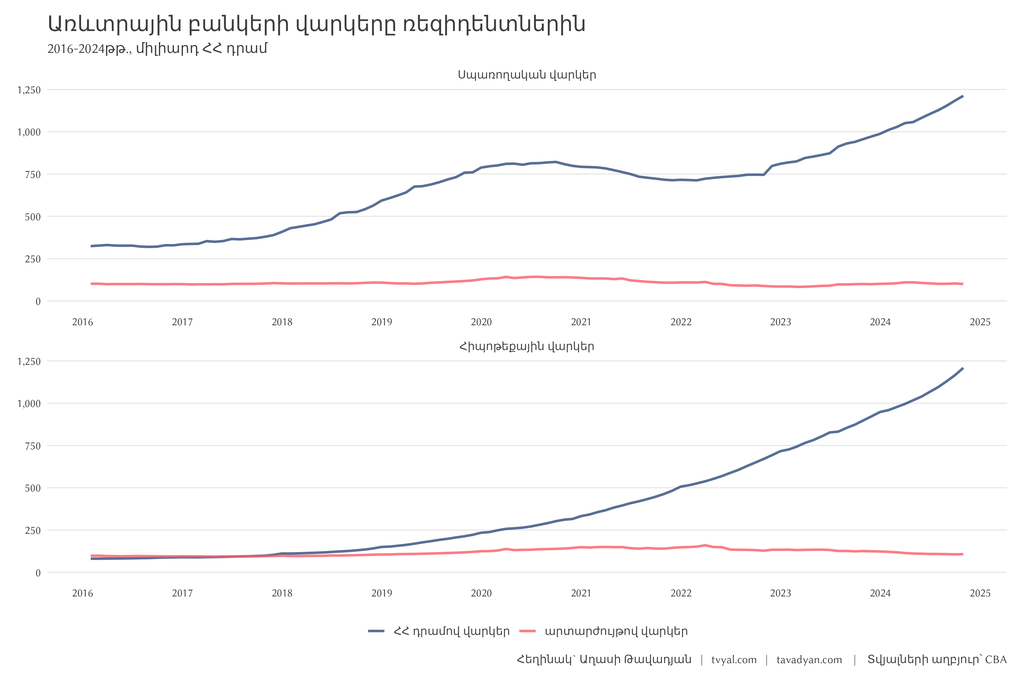

### Բանկային համակարգի շահերը

Այս որոշումից առաջին հերթին շահում է բանկային համակարգը: 2025թ․ հունվարից Երևանում հիպոթեքային վարկերի եկամտահարկի վերադարձի դադարեցումը կարող է բացասաբար անդրադառնալ կառուցապատողների և, որպես հետևանք, բանկային համակարգի վրա, քանի որ 2022թ․ բանկային համակարգ մուտք գործած գումարները հիմնականում ներդրվել են շինարարության ոլորտում։

### Վարկային բեռի դինամիկան

2024թ․ հոկտեմբերի 1-ի դրությամբ անհուսալի վարկ ունեցող ֆիզիկական անձ վարկառուների թիվը կազմում է շուրջ 341 հազար, իսկ նրանց վարկային բեռը՝ շուրջ 642 մլրդ դրամ: 2023թ․ ապրիլի դրությամբ այդ բեռը կազմել է 525 մլրդ դրամ: Հայաստանի աշխատունակ տարիքում գտնվող բնակչության թիվը կազմում է 2.2 մլն մարդ։ Այսինքն՝ աշխատունակ բնակչության 15.5 տոկոսն այս պահին ունի անհուսալի վարկ, որը չի կարող սպասարկել, և այդ ցուցանիշը շարունակում է աճել։

Գծապատկեր 3

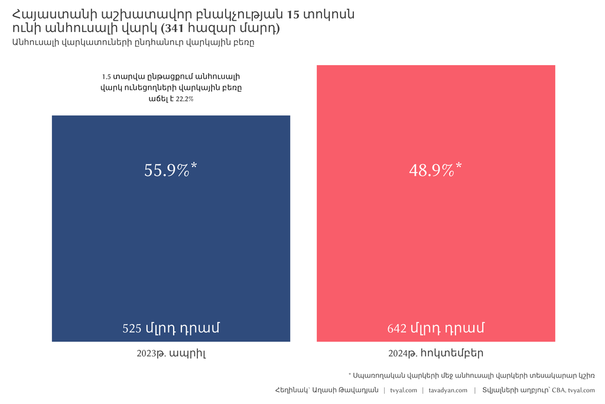

Գծապատկեր 4

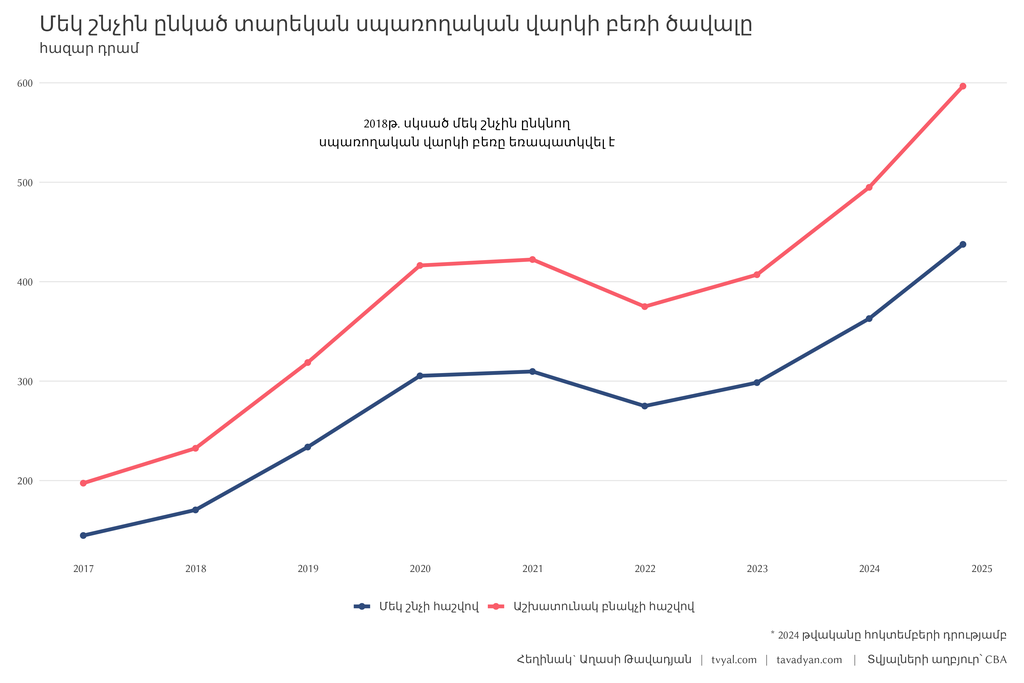

### Վարկավորման միտումները 2018-2024թթ․

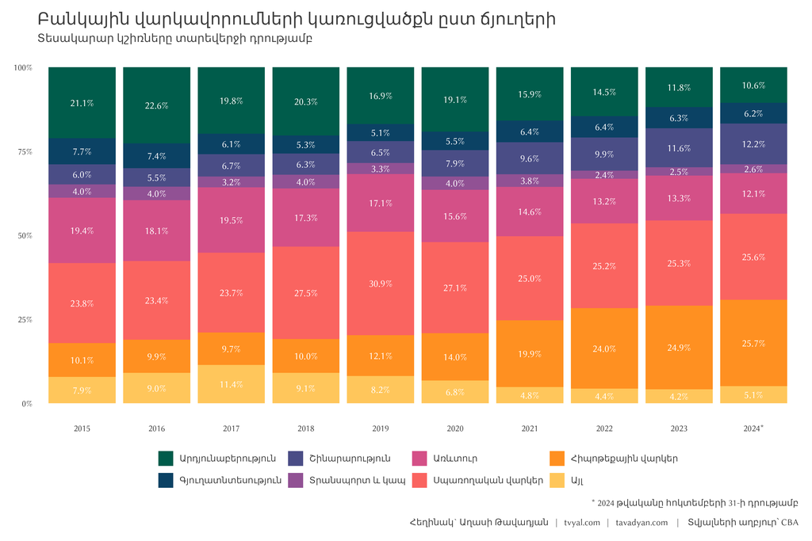

Նմանատիպ պատկեր է նաև սպառողական վարկերի դեպքում։ Այս վարկերի բեռը 2020 թվականից մինչև 2022 թվականի վերջ որոշակիորեն թեթևացել էր բնակչության համար, սակայն 2023 թվականից սկսած զգալիորեն աճել է։ Եթե 2021 թվականի վերջին սպառողական վարկերը կազմում էին 716 մլրդ դրամ, ապա այժմ դրանք գերազանցում են 1.2 տրիլիոն դրամը։ Փաստացի, սպառողական վարկերը 67 տոկոսով աճել են 3 տարվա ընթացքում։

### Սոցիալ-տնտեսական հետևանքները

Ինչպես նշել ենք մեր [նախորդ վերլուծություններում](https://www.tvyal.com/newsletter/2024/2024_09_30), այս պահին Հայաստանի իրական տնտեսությունը բարվոք վիճակում չէ, ինչի մասին վկայում են և՛ [հարկերի թերհավաքագրումը](https://www.tvyal.com/newsletter/2024/2024_11_19), և՛ դեպի ԵԱՏՄ ու ԵՄ արտահանման համապատասխանաբար 17 և 25 տոկոսով [կրճատումը](https://www.tvyal.com/newsletter/2024/2024_09_02)։

Անհուսալի վարկառուների վարկային բեռի սպասարկման գումարները պետք է որևէ աղբյուրից գոյանան, որպեսզի նաև սպասարկեն բանկային համակարգը 2025 թվականի անորոշ պայմաններում։ Դրանց մեծ մասը գալու է գործատուներից՝ հավելյալ հարկային բեռի տեսքով։ Սա կարող է խնդրահարույց լինել, քանի որ իրական տնտեսությունն այս պահին բարվոք վիճակում չէ։ Բացի այդ, կասկածելի է 220 հազար անհուսալի վարկառուների մասնակցությունը ծրագրին, քանի որ նրանք հիմնականում ցածր եկամուտ ունեցող կամ գործազուրկ անձինք են:

### Եզրակացություն

Առաջարկված վարկերի ներման ծրագիրը չի կարող հանդիսանալ համակարգային խնդիրների լիարժեք լուծում։ Այն ավելի շուտ ժամանակավոր միջոց է՝ միտված սոցիալական լարվածության մեղմմանը։ Փոխարենը անհրաժեշտ են հետևյալ քայլերը՝

- Սոցիալական քաղաքականության արմատական վերանայում
- Աշխատավարձերի բարձրացման և զբաղվածության ընդլայնման ծրագրերի մշակում
- Ֆինանսական գրագիտության բարձրացման համալիր միջոցառումներ
- Սպառողական վարկավորման ոլորտի կարգավորման նոր մեխանիզմների ներդրում

Առանց այս համակարգային բարեփոխումների՝ անհուսալի վարկերի թիվը և սպառողական վարկերի տեսակարար կշիռը շարունակելու են աճել՝ խորացնելով առկա սոցիալ-տնտեսական խնդիրները։

> **Ձեզ կարող է հետաքրքրել նաև**

> [💹🎏🏦 Վարկի տակ․ Վարկավորման միտումները ըստ ճյուղերի](https://www.tvyal.com/newsletter/2024/2024_06_07)

> [💎🎭🔮️ Ոսկե Պատրանք. Հայաստանի արտահանման իրական պատկերը](https://www.tvyal.com/newsletter/2024/2024_09_02)

> [🎭🇦🇲💸️ Վտանգավոր թվեր․ Հայաստանի տնտեսական «հրաշքի» մութ կողմ](https://www.tvyal.com/newsletter/2024/2024_11_19)

> [🚨📉🕵 Քողարկված անկում. Ինչո՞վ է ապրում Հայաստանի տնտեսությունը](https://www.tvyal.com/newsletter/2024/2024_09_30)

Եթե հնարավոր է, խնդրում եմ այս նյութը ուղարկել նաև այն մարդկանց, ում այն կարծում եք կարող է հետաքրքրել:

**ԱՅՍ ՀՈԴՎԱԾԻ ՀՂՈՒՄԸ**

*Թավադյան, Աղ․Ա․ (2024)․ Անհուսալի վարկառուների աջակցության ծրագիր. պոպուլիստական քայլ, թե՞ տնտեսական անհրաժեշտություն [USupport Program for Unreliable Borrowers: A Populist Move or Economic Necessity?]․ Tvyal.com հարթակ [Tvyal.com platform], 17-12-2024․ https://www.tvyal.com/newsletter/2024/2024_12_17*

**Արգելվում է այս հարթակի նյութերը արտատպել առանց հղում կատարելու։**

* Այս և մեր բոլոր այլ վերլուծությունների տվյալները վերցված են պաշտոնական աղբյուրներից։ Հաշվարկները ամբողջությամբ հասանելի են github-ում, դրանք կարելի է ստուգել` այցելելով [github-ի](https://github.com/tavad/tvyal_newsletter/blob/main/2024/) մեր էջը, որտեղ տրված են տվյալները, հաշվարկների և գծապատկերների կոդը։

# ՀԱՄԱԳՈՐԾԱԿՑՈՒԹՅՈՒՆ

## Եթե ուզում եք ձեր տվյլներից օգուտ քաղել AI գործիքներով` ԴԻՄԵՔ ՄԵԶ

### Մենք առաջարկում ենք

- Extensive databases for finding both international and local leads
- Exclusive reports on the Future of the Armenian Economy
- Work and browser automation to streamline operations and reduce staffing needs
- AI models for forecasting growth and optimizing various aspects of your business
- Advanced dashboarding and BI solutions
- Algorithmic trading

### Let’s Put Your Data to Work!

### ՄԻԱՑԵՔ ՄԵՐ ԹԻՄԻՆ

## ԶԼՄ հաղորդագրություն

[Դիտեք news.am-ին տրված իմ ակնարկը այս թեմայի մասին](https://youtu.be/WbS1mjPK1Qw)

📺 Նախընտրական կաշա՞ռք. ինչու է Փաշինյանն օգնում անհուսալի վարկառուներին 📺

[figure not shown]

[Դիտեք 1in.am-ին տրված հարցազրույցը 2025 թվականի հարկային փոփոխությունների մաիսն](https://youtu.be/tqXdEhCI3ok?t=11)

📺 Կառավարության ընդունած հարկային փոփոխություններն ավելի է վատացնելու բնակչության սոցիալական վիճակը 📺

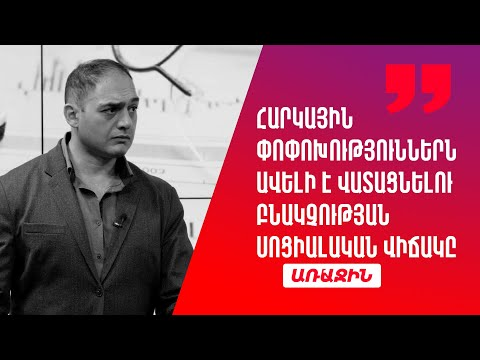

## English Summary

### 💳🚨🏦 Support Program for Unreliable Borrowers: A Populist Move or Economic Necessity?

Հարգանքներով,  
Աղասի Թավադյան  
17.12.2024  
[tvyal.com](https://www.tvyal.com/)  
[tavadyan.com](https://www.tavadyan.com/)

[Was this email forwarded to you? Subscribe here.](https://www.tvyal.com/subscribe)

[Բաժանորդագրվեք](https://www.tvyal.com/subscribe)

**Ուշադրություն. Ձեր էլ.փոստը մեյլլիսթի մեջ է, որի միջոցով ես կիսվում եմ շաբաթական նյութեր, որոնք հիմնականում ներկայացնում են Հայաստանի տնտեսությունը: Նյութերը ներառում են գծապատկերներ, [տվյալների բազաներ](https://github.com/tavad/tvyal_newsletter), տեսանյութեր, հոդվածներ, [առցանց վահանակներ](https://www.tvyal.com/projects), տնտեսական գործիքներ, կանխատեսումներ և հաշվետվություններ: Եթե ցանկանում եք չեղարկել բաժանորդագրությունը, խնդրում եմ տեղեկացրեք ինձ, և ես կհեռացնեմ ձեր էլ. փոստը ցուցակից: Գրեք նաև եթե ունեք մենկնաբանություններ:**

**Important! Your email is part of the mailing list where I share weekly materials primarily focused on the Armenian economy. These materials encompass charts, [databases](https://github.com/tavad/tvyal_newsletter), videos, articles, [online dashboards](https://www.tvyal.com/projects), economic tools, forecasts, and reports. If you wish to unsubscribe, please let me know, and I will remove your email from the list. Please share your comments as well․**